# 第６回 構造化プログラミング

プログラミング演習Ⅱ

佐藤 秀保

sato0035@toyo.jp

## 先週までの内容

- 文字列の抽出方法（リストと同様）
- 文字列の長さ・連結（リストと同様）
- strクラスのメソッド
  - replace/index/count/split
- スクレイピング
- 自然言語処理（NLP）
- エスケープシーケンス \

## 準備

1. [Colab](https://colab.research.google.com/?hl=ja).にアクセス
2. 左下「ノートブックを新規作成」
3. 左上のノートブック名を「lec6」などに変更
4. 右側に「リリースノート」が出る場合は×で消す

## 構造化プログラミング

- **制御構造**（いつどんな条件で命令を実行するか，その流れを制御する仕組み）を明確にし，理解・保守しやすくするプログラム設計の思想
- すべての**アルゴリズム**（ある処理を達成するための有限個の手順の集まり）は３つの制御構造で記述可
  - **順次 sequence**：上から順に命令を実行
  - **選択 selection**：条件により処理を分ける
  - **反復 iteration**：条件が成立する間，処理を繰り返す

## 選択 selection

### if else文

- 文法

```python
#以下は実行しないで下さい
if 条件式:
  条件式が真 True のとき実行するコード
else:
  条件式が偽 False のとき実行するコード
```

- 注意点
  - インデント（字下げ）が実行コード部分に必要
  - Pythonでは，インデントによって処理に関するグループを区別
  - Rでは，インデントはコードの可読性を高める以外の意味はなし
  - 改行する際に自動でインデントされるが，手動でインデントを入れる場合は**Tabキー**
- 例：

```python
calories = 900
if calories >= 2700:
  print("今日は食べすぎです")
else:
  print("いいね！")
```

### if elif else文

- 文法

```python
#以下は実行しないで下さい
if 条件式１:
  条件式１が真 True のとき実行するコード
elif 条件式２:
  条件式１が偽 False かつ条件式２が真 True のとき実行するコード
else:
  条件式１が偽 False かつ条件式２が偽 False のとき実行するコード
```

- 例１：条件式が２つ

```python
calories = 900
if calories >= 2700:
  print("今日は食べすぎです")
elif calories < 1000:
  print("危険！今すぐ何かを食べて！")
else:
  print("いいね！")
```

- 例２：条件式が３つ
  - `elif` を増やして複数の条件式に対応すればOK

```python
calories = 900
if calories >= 2700:
  print("今日は食べすぎです")
elif calories < 1000:
  print("危険！今すぐ何かを食べて！")
elif calories < 1500:
  print("今日はカロリー不足気味です")
else:
  print("いいね！")
```

- 悪い例：

```python
calories = 900
if calories >= 2700:
  print("今日は食べすぎです")
elif calories < 1500:
  print("今日はカロリー不足気味です")
elif calories < 1000:
  print("危険！今すぐ何かを食べて！")
else:
  print("いいね！")
```

※制御構造を意識してコードを書くこと！

### 演習１

- 条件式を３つ以上使用したif elif else文を自由に書いて，実行せよ．

### if文のネスト構造

- if文の中にif文を書くことも可

```python
calories = 900
if calories >= 2700:
  print("今日は食べすぎです")
else:
  if calories < 1000:
    print("危険！今すぐ何かを食べて！")
  else:
    if calories < 1500:
      print("今日はカロリー不足気味です")
    else:
      print("いいね！")
```

- 注意点
  - 前スライドのコードは，if elif else文の「例２：条件式が３つ」と同値
  - インデントレベル（深さ）により処理のグループを区別

### 複数の条件式

- `and` や `or` で複数の条件式の考慮が可

```python
calories = 900
veggies = True #野菜を食べたか

if calories < 1500 and veggies:
  print("カロリーは少なめですが，野菜が摂れていて良いですね．")
elif calories < 1500 and not veggies:
  print("食事量が少なく，野菜も不足しています．バランスを見直しましょう．")
elif calories >= 2700 or not veggies:
  print("少し食べすぎか，野菜が足りないかもしれません．気をつけましょう．")
else:
  print("カロリーも野菜もバランスの良い食事です！")
```

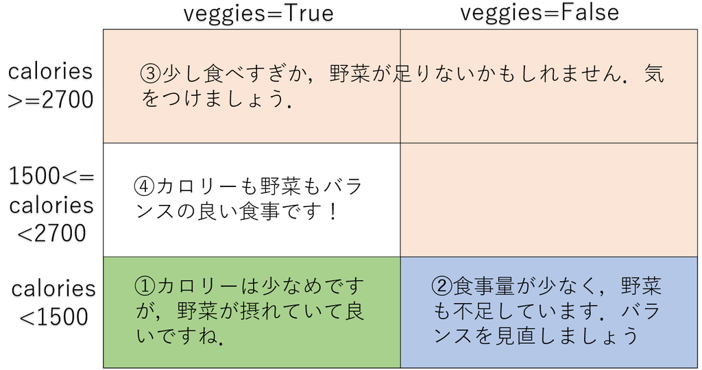

## 反復 iteration

### for文

- 文法

```python
#以下は実行しないで下さい
for 変数 in イテラブル:
  実行するコード
```

- イテラブル：１つずつ順番に取り出せるもの
  - リスト，タプル，辞書，文字列など
- 注意点：
  - for文では，イテラブルから要素を１つずつ取り出し変数に代入しながらコードを順に実行し，すべての要素を取り出し終えると実行が終了
  - ここでもインデントが必要
- 例１：

```python
list1 = [1, 2, 3]
for i in list1:
  print(i)
```

1. `list1` から`1`を取り出し，`i` に代入
2. `print(i)` を実効（`i=1`なので`1`と表示）
3. `list1` から`2`を取り出し，`i` に代入
4. `print(i)` を実効（`i=2`なので`2`と表示）
5. `list1` から`3`を取り出し，`i` に代入
6. `print(i)` を実効（`i=3`なので`3`と表示）
- 例２：

```python
list1 = [1, 2, 3]
for i in list1:
  print(i)
print("おしまい")
```

- 最後の`print("おしまい")` は，インデントされていない．
- つまり，ループの外にあり，ループ実行終了後の順次処理となる．
- 例３：イテラブルが文字列

```python
string1 = "あいうえお"
for s in string1:
  print(s)
```

- 例４：イテラブルが辞書

```python
dict1 = {"apple":200, "orange":150, "grape":1000}
for d in dict1:
  print(d) #キーが返る
```

```python
for d in dict1.values():
  print(d) #値が返る
```

- デフォルトでは`key` メソッドが適用され，キーが返る
- `values` メソッドを使えば，値を返せる

※`key` メソッド，`values` メソッドは第４講を参照

### イテラブルに`range`を使用

- `range`関数は整数の組を`range` クラスのオブジェクトとして生成
  - `range(4)` は`0 1 2 3`
  - `range(1,4)` は`1 2 3`
  - `range(1,4,2)` は`1 3`
- `range` クラスのオブジェクトは，整数の組が入ったリストのようなもの

```python
for i in range(4):
  print(i)
```

### for文のネスト構造

- for文の中にfor文を書くことも可

```python
for i in [1,2,3,4,5]:
  for j in "あいう":
    print(i, j)
```

- 少し実践的な例

```python
firms = "ABCDE" #企業名A,B,...
products = [1, 2, 3, 4, 5] #商品の種類番号1,2,...
for f in firms:
  for prdct in products:
    print("企業" + f + "_商品" + str(prdct)) #str関数で文字列化して連結
```

### インクリメント

- インクリメント increment は，変数の値を一定量（通常は +1）だけ増やすこと

```python
count = 0
for i in range(4):
  count = count + 1
  print(count)
```

- 注意点：ループの中で`i`が登場しなくても問題なし
- 以上のような累算代入は短縮形の表現がある；

```python
count = 0
for i in range(4):
  count += 1 #短縮形
  print(count)
```

- 第５講「応用２」のつづき
- 以下の価格データ`data_prices`を適切に分割しリストとして保存せよ．

```python
data_prices = "2,980; 1,980; 20,000; 8,500"

str1 = data_prices.replace(",", "") #コンマ削除
str2 = str1.split(";") #リスト化
print(str2) #まだリストの中は文字列．数値にしたい．
```

- 方針：
  1. 空のリストを用意
  2. 文字列の入ったリスト`str2`の要素に繰り返し`int`関数を適用し整数化しリストに入れる
  3. 空のリストに整数化した要素をインクリメントでくっつけていく

```python
price_list = []
for p in str2:
  price_list += [int(p)] #リストの足し算は結合
print(price_list)
```

### 演習２

- 以下の摂取カロリーデータ`data_calories`をコンマ`,`で分割してリストの要素とし，それぞれの要素を整数に変換して保存せよ．

```python
data_calories = "2500, 1980, 1840, 2660, 1440"
```

## 構造化プログラミングの小話

- 1950-60年代，条件分岐の際には「goto文」を用いて別の場所に飛ぶコーディング
  - 網の目のように入り組んだスパゲッティコードに
- 1968年，オランダの学者ダイクストラ氏が寄稿「Go To Statement Considered Harmful」でgoto文の批判と「順次・選択・反復」による基本構造の重要性を強調
- 1969年，ダイクストラ氏は論文「Structured Programming」（構造化プログラミング）で包括的なプログラミング方法論を主張
- 世間は1968年と1969年の内容を混同し，「構造化プログラミング」の名で1968年の内容が伝播

## 課題

- ACEの小テスト：「第６回」
- ACEのレポート：「第６回」
  - ノートブックを提出（方法は第１回資料参照）